# R Markdown document One

Adrián González

19 de Mayo de 2019

# This is a level 1 Header

## R Markdown

### This is a level 3 Header

Here is a link to [GOOGLE](http://google.com)

Here is a word in **bold** and another word in **bold**.

Here is a word in *italics* and another word in *italics*.

when we compile our document, we are using the `rmarkdown` package

Here are some example R comands:

```
2+2
mean(c(1,2,3,4,5,6))
```

Here is an example of a non-numbered list:

- Breakfast
  - food
    - eggs
    - toast
    - bacon
  - drink
    - apple juice
- Lunch
  - taco
- Dinner
  - baked chicken
  - broccoli
  - rice

Here is an example of a numbered list:

1. Breakfast
   1. food
      1. eggs
      2. toast
      3. bacon
   2. drink
      1. apple juice
2. Lunch
   1. taco
3. Dinner
   1. baked chicken
   2. broccoli
   3. rice

Here is an example of blockquote:

> This is a block quote. This paragraph has two lines.
> 1. This is a list inside a blocj quote.
> 2. Second items

Here is an example of nested blockquote:

> This is a block quote. This paragraph has two lines

> > This text is nested

Here is an example of code in a blockquote:

> ```
>  2+2
>  mean(c(1,2,3,4,5))
> ```

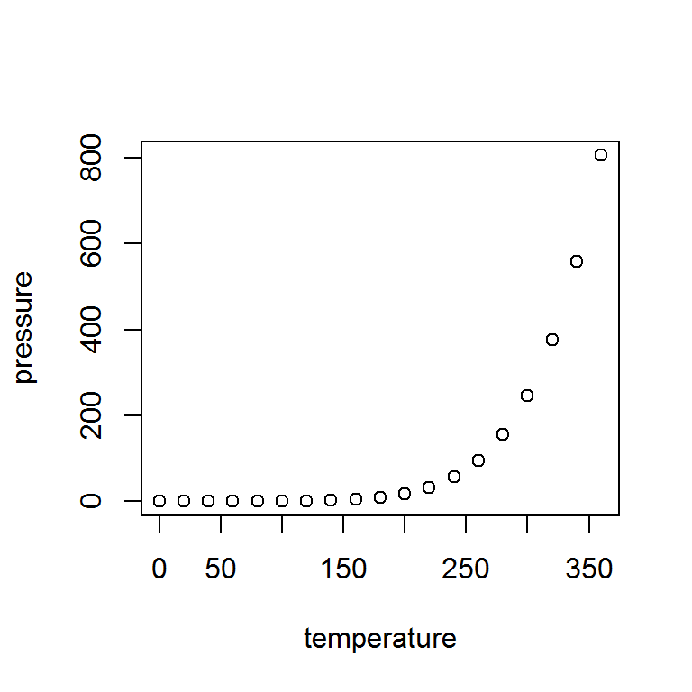

## Insert tables

```r
knitr::kable(head(cars),
             caption = "Top 6 Rows of Cars Dtaset")
```

Top 6 Rows of Cars Dtaset

| speed | dist |
| --- | --- |
| 4 | 2 |
| 4 | 10 |
| 7 | 4 |
| 7 | 22 |
| 8 | 16 |
| 9 | 10 |

## Insert Images

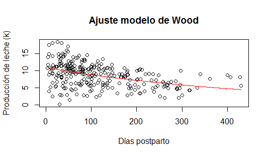

Ajustando producción de leche (kg) al modelo de Wood